# Lab 2 - Mason Brehmer

[View the GitHub Repository](https://github.com/masonbrehmer/GSB_544_Labs/tree/main)

```python
import pandas as pd
import numpy as np
import plotnine as p9
#looked on chat how to get rid of scientific notation in python
pd.set_option('display.float_format', '{:.2f}'.format)
```

```python
# Import the avocado dataset
avocado = pd.read_csv(r"C:\Users\mason\OneDrive\Desktop\GSB_544_Labs\Lab 2\avocado-updated-2020.csv")

# Check data types and non-null counts
# avocado.info() don't want it in the final output
```

1.Briefly describe the data set. What information does it contain?

2. Clean the data in any way you see fit.

```python
# Creating a variable containing just the names of the defined main regions
main_regions = ["California", "Great Lakes", "Midsouth", "Northeast",
                "Plains", "Southeast", "South Central", "West"]

# Used chat to create a variable called cities with all the city names within the dataset
cities = [
    "Albany", "Atlanta", "Baltimore/Washington", "Boise", "Boston",
    "Buffalo/Rochester", "Charlotte", "Chicago", "Cincinnati/Dayton",
    "Columbus", "Dallas/Ft. Worth", "Denver", "Detroit", "Grand Rapids",
    "Harrisburg/Scranton", "Hartford/Springfield", "Houston", "Indianapolis",
    "Jacksonville", "Las Vegas", "Los Angeles", "Louisville",
    "Miami/Ft. Lauderdale", "Nashville", "New Orleans/Mobile", "New York",
    "Orlando", "Philadelphia", "Phoenix/Tucson", "Pittsburgh", "Portland",
    "Raleigh/Greensboro", "Richmond/Norfolk", "Roanoke", "Sacramento",
    "San Diego", "San Francisco", "Seattle", "Spokane", "St. Louis",
    "Syracuse", "Tampa", "West Tex/New Mexico",
]

#Used chat to find any of the other names wihtin the dataset.
other = [
    "Northern New England", "South Carolina"
]

# Total U.S.
US = [
    "Total U.S."
]
```

```python
# Making the avocado_clean dataset with the data cleaned.
avocado_clean = avocado.copy()

# Adding in the geo_type column using .where logic
avocado_clean["geo_type"] = "other"
avocado_clean.loc[avocado_clean["geography"].isin(main_regions), "geo_type"] = "region"
avocado_clean.loc[avocado_clean["geography"].isin(cities), "geo_type"] = "city"
avocado_clean.loc[avocado_clean["geography"].isin(US),"geo_type"] = "US"
```

```python
# Changing the numbered avocado column names to their correct terms.
avocado_clean = avocado_clean.rename(columns={
    "4046": "small_avocado",
    "4225": "large_avocado",
    "4770": "xlarge_avocado"
})

#Preview our cleaned dataset
avocado_clean.head()
```

|  | date | average_price | total_volume | small_avocado | large_avocado | xlarge_avocado | total_bags | small_bags | large_bags | xlarge_bags | type | year | geography | geo_type |
| --- | --- | --- | --- | --- | --- | --- | --- | --- | --- | --- | --- | --- | --- | --- |
| 0 | 2015-01-04 | 1.22 | 40873.28 | 2819.50 | 28287.42 | 49.90 | 9716.46 | 9186.93 | 529.53 | 0.00 | conventional | 2015 | Albany | city |
| 1 | 2015-01-04 | 1.79 | 1373.95 | 57.42 | 153.88 | 0.00 | 1162.65 | 1162.65 | 0.00 | 0.00 | organic | 2015 | Albany | city |
| 2 | 2015-01-04 | 1.00 | 435021.49 | 364302.39 | 23821.16 | 82.15 | 46815.79 | 16707.15 | 30108.64 | 0.00 | conventional | 2015 | Atlanta | city |
| 3 | 2015-01-04 | 1.76 | 3846.69 | 1500.15 | 938.35 | 0.00 | 1408.19 | 1071.35 | 336.84 | 0.00 | organic | 2015 | Atlanta | city |
| 4 | 2015-01-04 | 1.08 | 788025.06 | 53987.31 | 552906.04 | 39995.03 | 141136.68 | 137146.07 | 3990.61 | 0.00 | conventional | 2015 | Baltimore/Washington | city |

3. Which major geographical region sold the most total organic, small Hass avocados in 2017?

```python
#Creating a new dataset called avocado_clean_so for question 3 finding which region sells the most small avocadoes.
avocado_clean_so = avocado_clean[avocado_clean["geo_type"] == "region"]

avocado_clean_so = avocado_clean_so[avocado_clean_so["year"] == 2017]

avocado_clean_so = avocado_clean_so[avocado_clean_so["type"] == "organic"]

avocado_clean_so = avocado_clean_so[avocado_clean_so["geo_type"]== "region"]
```

```python
region_small_totals = (
avocado_clean_so.groupby("geography")["small_avocado"]
    .sum()
    .sort_values(ascending=False)
)

# Display the results
region_small_totals
```

```
geography
West            1870206.29
South Central   1717104.19
California      1526290.58
Northeast        925832.36
Southeast        285124.34
Great Lakes      202487.68
Midsouth         186395.50
Plains           168583.40
Name: small_avocado, dtype: float64
```

As the sum output shows, the West region produced the largest volume of organic, small avocadoes at 1,870,206.29 in the year 2017.

4. Split the date variable into month, day, and year variables. In which month is the highest average volume of avocado sales?

```python
# Converting the data into datetime to work with my function
avocado_clean["date"] = pd.to_datetime(avocado_clean["date"])
#Adding columns for month, day, and a new year column in case some data doesn't match.
avocado_clean["month"] = avocado_clean["date"].dt.month
avocado_clean["day"] = avocado_clean["date"].dt.day
avocado_clean["year2"] = avocado_clean["date"].dt.year
```

```python
# Creating a new dataset that only includes Total U.S. Sales for each year.
avocado_clean_TUS = avocado_clean[avocado_clean["geo_type"] == "US"]
```

```python
#Finding the highest monthly average.
highest_monthly_avg = (
avocado_clean_TUS.groupby("month")["total_volume"]
    .mean()
    .sort_values(ascending=False)
)

# Display the results
highest_monthly_avg
```

```
month
5    22932034.62
2    22367902.58
6    21449466.90
4    20771602.70
3    20356402.22
1    20114322.51
7    20096959.86
8    19385656.75
9    18474392.39
10   17195826.66
11   16736513.65
12   16455960.41
Name: total_volume, dtype: float64
```

As we can see by our output, month 5 which is MAY has the largest average total volume of avocados sold.

5. Which metro area geographical regions sold the most total avocados? Plot side-by-side box-plots of the total volume for only the five metro geographical regions with the highest averages for the total_volume variable.

```python
# Creating a new dataset that only includes Total U.S. Sales for each year.
avocado_clean_metro = avocado_clean[avocado_clean["geo_type"] == "city"]
```

```python
#First I am going to use a mean function to find the top 5 metros. Remember I defined all of the cities within the geography column as a metro area.

top5_metros = (
    avocado_clean_metro.groupby("geography")["total_volume"]
    .mean()
    .sort_values(ascending=False)
    .head(5)
)

top5_metros
```

```
geography
Los Angeles        1567566.16
New York            863145.82
Dallas/Ft. Worth    712751.90
Houston             687653.34
Phoenix/Tucson      625038.26
Name: total_volume, dtype: float64
```

We can see from the output that the Los Angeles metro region sold the most total avocados overall.

```python
# Creating a variable Metros that includes the top 5 metros we found above.
Metros = [
        "Los Angeles", "New York", "Dallas/Ft. Worth", "Houston", "Phoenix/Tucson"
]
#Now creating another new dataset that includes only the top 5 metro areas.
avocado_top5 = avocado_clean_metro[
    avocado_clean_metro["geography"].isin(Metros)
]
```

Below is the boxplot for our top 5 metro cities.

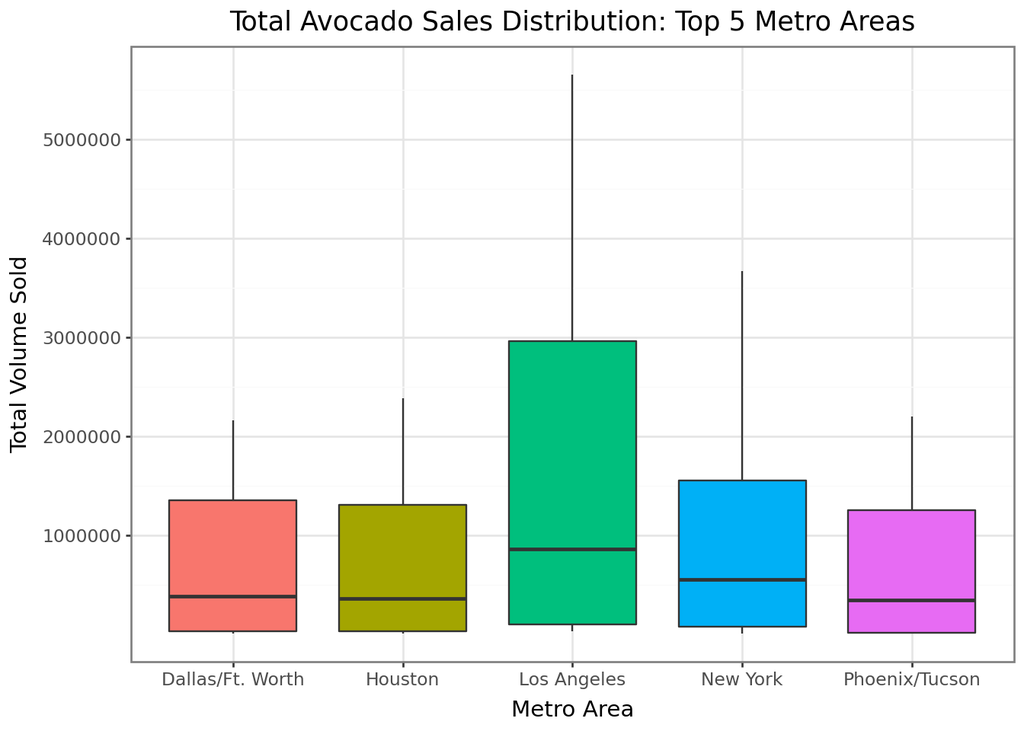

```python
# Used chat to help me define more breaks to make the visualization more understandable.
y_axis_breaks = [1000000, 2000000, 3000000, 4000000, 5000000]

top_5_plot = (
    p9.ggplot(avocado_top5, p9.aes(x="geography", y="total_volume", fill="geography"))
    + p9.geom_boxplot(show_legend=False)
    + p9.scale_y_continuous(breaks=y_axis_breaks)
    + p9.labs(
        title="Total Avocado Sales Distribution: Top 5 Metro Areas",
        x="Metro Area",
        y="Total Volume Sold"
            )

    + p9.theme_bw()
)

top_5_plot
```

6. From your cleaned data set, create a data set with only these California regions and answer the following questions about these California regions only.

```python
#Creating a variable California with all the cities we are looking at
California = [
    "Los Angeles", "San Diego", "Sacramento","San Francisco"
]
# Creating a new dataset with the variables we need.
avocado_california = avocado_clean[avocado_clean["geography"].isin(California)]
avocado_california.head()
```

|  | date | average_price | total_volume | small_avocado | large_avocado | xlarge_avocado | total_bags | small_bags | large_bags | xlarge_bags | type | year | geography | geo_type | month | day | year2 |
| --- | --- | --- | --- | --- | --- | --- | --- | --- | --- | --- | --- | --- | --- | --- | --- | --- | --- |
| 44 | 2015-01-04 | 0.85 | 2682159.95 | 1837999.65 | 524430.47 | 64225.78 | 255504.05 | 215571.80 | 36981.72 | 2950.53 | conventional | 2015 | Los Angeles | city | 1 | 4 | 2015 |
| 45 | 2015-01-04 | 1.25 | 54495.54 | 47721.51 | 1723.40 | 0.00 | 5050.63 | 5050.63 | 0.00 | 0.00 | organic | 2015 | Los Angeles | city | 1 | 4 | 2015 |
| 80 | 2015-01-04 | 1.05 | 430138.88 | 110693.69 | 270107.61 | 9737.50 | 39600.08 | 39600.08 | 0.00 | 0.00 | conventional | 2015 | Sacramento | city | 1 | 4 | 2015 |
| 81 | 2015-01-04 | 1.33 | 9213.49 | 3727.52 | 4327.52 | 0.00 | 1158.45 | 1158.45 | 0.00 | 0.00 | organic | 2015 | Sacramento | city | 1 | 4 | 2015 |
| 82 | 2015-01-04 | 0.94 | 461607.33 | 244152.26 | 165299.33 | 15302.75 | 36852.99 | 30884.29 | 5595.00 | 373.70 | conventional | 2015 | San Diego | city | 1 | 4 | 2015 |

7. In which California regions is the price of organic versus conventional avocados most different? Support your answer with a few summary statistics AND a visualization.

```python
#Creating two different datasets one with only california/organic and one with california/conventional.
avocado_california_organic = avocado_california[avocado_california["type"]=="organic"]
avocado_california_organic.head()

avocado_california_not = avocado_california[avocado_california["type"]!="organic"]
avocado_california_not.head()
```

|  | date | average_price | total_volume | small_avocado | large_avocado | xlarge_avocado | total_bags | small_bags | large_bags | xlarge_bags | type | year | geography | geo_type | month | day | year2 |
| --- | --- | --- | --- | --- | --- | --- | --- | --- | --- | --- | --- | --- | --- | --- | --- | --- | --- |
| 44 | 2015-01-04 | 0.85 | 2682159.95 | 1837999.65 | 524430.47 | 64225.78 | 255504.05 | 215571.80 | 36981.72 | 2950.53 | conventional | 2015 | Los Angeles | city | 1 | 4 | 2015 |
| 80 | 2015-01-04 | 1.05 | 430138.88 | 110693.69 | 270107.61 | 9737.50 | 39600.08 | 39600.08 | 0.00 | 0.00 | conventional | 2015 | Sacramento | city | 1 | 4 | 2015 |
| 82 | 2015-01-04 | 0.94 | 461607.33 | 244152.26 | 165299.33 | 15302.75 | 36852.99 | 30884.29 | 5595.00 | 373.70 | conventional | 2015 | San Diego | city | 1 | 4 | 2015 |
| 84 | 2015-01-04 | 0.99 | 907795.89 | 179507.69 | 637000.10 | 8803.79 | 82484.31 | 82033.71 | 444.44 | 6.16 | conventional | 2015 | San Francisco | city | 1 | 4 | 2015 |
| 152 | 2015-01-11 | 0.85 | 2713699.60 | 1786326.65 | 617233.39 | 58892.91 | 251246.65 | 222971.68 | 25111.74 | 3163.23 | conventional | 2015 | Los Angeles | city | 1 | 11 | 2015 |

```python
#Finding average organic sale price.
avg_sp_organic = (
    avocado_california_organic.groupby("geography")["average_price"]
    .mean()
    .sort_values(ascending=False)
)

avg_sp_organic
```

```
geography
San Francisco   2.12
Sacramento      1.87
San Diego       1.80
Los Angeles     1.57
Name: average_price, dtype: float64
```

```python
#Finding average conventional sale price.
avg_sp_nonorg = (
    avocado_california_not.groupby("geography")["average_price"]
    .mean()
    .sort_values(ascending=False)
)

avg_sp_nonorg
```

```
geography
San Francisco   1.40
Sacramento      1.30
San Diego       1.11
Los Angeles     1.05
Name: average_price, dtype: float64
```

```python
#I asked chat what the best way of computing the difference with code would be and it told me to merge the two tables I've just created with this code.

# Convert to dataframes
avg_sp_organic_df = avg_sp_organic.to_frame(name="avg_price_organic").reset_index()
avg_sp_nonorg_df = avg_sp_nonorg.to_frame(name="avg_price_conventional").reset_index()

# Merge on geography
price_diff = avg_sp_organic_df.merge(avg_sp_nonorg_df, on="geography")


# Then I just created a new column that was the average price of organic subtracted by avg price of conventional.
price_diff["price_difference"] = (
    price_diff["avg_price_organic"] - price_diff["avg_price_conventional"]
)

price_diff.head()
```

|  | geography | avg_price_organic | avg_price_conventional | price_difference |
| --- | --- | --- | --- | --- |
| 0 | San Francisco | 2.12 | 1.40 | 0.72 |
| 1 | Sacramento | 1.87 | 1.30 | 0.58 |
| 2 | San Diego | 1.80 | 1.11 | 0.68 |
| 3 | Los Angeles | 1.57 | 1.05 | 0.53 |

From this table output, it’s easy to see that the largest price difference between organic and conventional avocados is in the San Francisco region and is .72$. The visualization below also allows us to see that San Francisco has the largest difference with Los Angeles having the smallest difference.

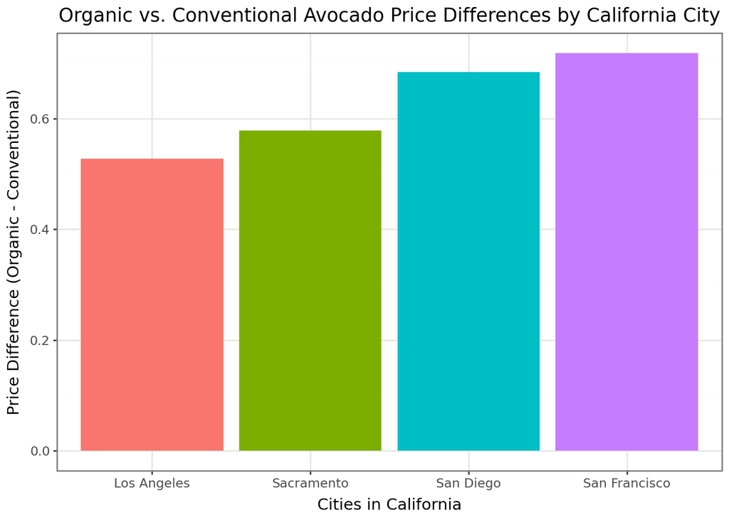

```python
#Creating bar charts for each california city to see the differences between each cities (organic v. conventional) price differences.
price_diff_vis = (
    p9.ggplot(price_diff, p9.aes(x="geography", y="price_difference", fill = "geography"))
    + p9.geom_col(show_legend=False)
    + p9.theme_bw()
    + p9.labs(
        title="Organic vs. Conventional Avocado Price Differences by California City",
        x="Cities in California",
        y="Price Difference (Organic - Conventional)"
    )

)

price_diff_vis
```

8. The following plot shows, for all four California regions, the proportion of the average Hass avocado sales that are small, large, or extra large; conventional vs. organic. Recreate the plot; you do not have to replicate the exact finishing touches - e.g., color, theme - but your plot should resemble the content of this plot.

```python
#Keeping only the columns we need to create the visualization
avocado_california = avocado_california[["geography", "type","small_avocado","large_avocado","xlarge_avocado"]]
```

```python
# Creating three new columns with the mean avocado sale volume for each size avocado.
avocado_california["avg_small"] = avocado_california.groupby(
    ["geography", "type"]
)["small_avocado"].transform("mean")

avocado_california["avg_large"] = avocado_california.groupby(
    ["geography", "type"]
)["large_avocado"].transform("mean")

avocado_california["avg_xlarge"] = avocado_california.groupby(
    ["geography", "type"]
)["xlarge_avocado"].transform("mean")
```

```python
#Creating a total average volume column by adding each size value together.
avocado_california["total_avg_volume"] = (
    avocado_california["avg_small"]
    + avocado_california["avg_large"]
    + avocado_california["avg_xlarge"]
)
```

```python
#Creating columns for the proportion of each size of avocado sale volume to the total sale volume
avocado_california["small"] = (
    avocado_california["avg_small"] / avocado_california["total_avg_volume"]
)
avocado_california["large"] = (
    avocado_california["avg_large"] / avocado_california["total_avg_volume"]
)
avocado_california["xlarge"] = (
    avocado_california["avg_xlarge"] / avocado_california["total_avg_volume"]
)
```

```python
#Asked chat what the best way to make it so only one record of each cities ratio for both conventional and organic.
avocado_california = avocado_california.drop_duplicates(subset=["geography", "type"])
```

```python
# Changed the dataset to have one size and proportion column for all sizes.
avocado_california = avocado_california.melt(
    id_vars=["geography", "type"],
    value_vars=["small", "large", "xlarge"],
    var_name="size",
    value_name="proportion"
)

# Plot initially had the bars stacked in a strange order so I asked if there was a function to ensure that the bars go from small > large > xlarge.
avocado_california["size"] = pd.Categorical(
    avocado_california["size"],
    categories=["xlarge", "large", "small"],
    ordered=True
)

avocado_california.head()
```

|  | geography | type | size | proportion |
| --- | --- | --- | --- | --- |
| 0 | Los Angeles | conventional | small | 0.68 |
| 1 | Los Angeles | organic | small | 0.41 |
| 2 | Sacramento | conventional | small | 0.36 |
| 3 | Sacramento | organic | small | 0.40 |
| 4 | San Diego | conventional | small | 0.51 |

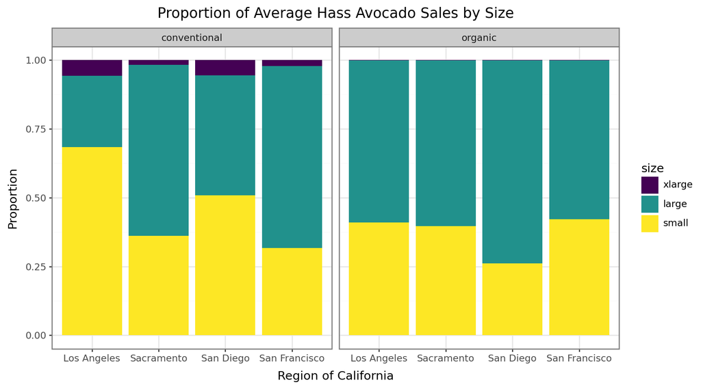

```python
# Remaking plot from the lab
plot_remake = (
    p9.ggplot(
        avocado_california,
        p9.aes(x="geography", y="proportion", fill="size")
        )
    + p9.geom_col(position="fill")
    #Asked chat what plotnine funciton would let me have two different charts side by side
    + p9.facet_wrap("~type")
    + p9.labs(
        title="Proportion of Average Hass Avocado Sales by Size",
        x="Region of California",
        y="Proportion"
    )
    + p9.theme_bw()
    + p9.theme(
        figure_size=(9, 5)
    )
)

plot_remake
```

9. Joining new Dataset

```python
#Creating a variable California with all the cities we are looking at
California = [
    "Los Angeles", "San Diego", "Sacramento","San Francisco"
]
# Creating a new dataset with the variables we need.
avocado_california_old = avocado_clean[avocado_clean["geography"].isin(California)]
avocado_california_old.head()
```

|  | date | average_price | total_volume | small_avocado | large_avocado | xlarge_avocado | total_bags | small_bags | large_bags | xlarge_bags | type | year | geography | geo_type | month | day | year2 |
| --- | --- | --- | --- | --- | --- | --- | --- | --- | --- | --- | --- | --- | --- | --- | --- | --- | --- |
| 44 | 2015-01-04 | 0.85 | 2682159.95 | 1837999.65 | 524430.47 | 64225.78 | 255504.05 | 215571.80 | 36981.72 | 2950.53 | conventional | 2015 | Los Angeles | city | 1 | 4 | 2015 |
| 45 | 2015-01-04 | 1.25 | 54495.54 | 47721.51 | 1723.40 | 0.00 | 5050.63 | 5050.63 | 0.00 | 0.00 | organic | 2015 | Los Angeles | city | 1 | 4 | 2015 |
| 80 | 2015-01-04 | 1.05 | 430138.88 | 110693.69 | 270107.61 | 9737.50 | 39600.08 | 39600.08 | 0.00 | 0.00 | conventional | 2015 | Sacramento | city | 1 | 4 | 2015 |
| 81 | 2015-01-04 | 1.33 | 9213.49 | 3727.52 | 4327.52 | 0.00 | 1158.45 | 1158.45 | 0.00 | 0.00 | organic | 2015 | Sacramento | city | 1 | 4 | 2015 |
| 82 | 2015-01-04 | 0.94 | 461607.33 | 244152.26 | 165299.33 | 15302.75 | 36852.99 | 30884.29 | 5595.00 | 373.70 | conventional | 2015 | San Diego | city | 1 | 4 | 2015 |

```python
# Import the housing dataset
housing = pd.read_csv(r"C:\Users\mason\OneDrive\Desktop\GSB_544_Labs\Lab 2\Housing_data_redfin.csv")
housing.head()
housing.columns
```

```
Index(['Region', 'Year of Period End', 'Median Sale Price'], dtype='object')
```

```python
#Renaming the column names so the join is easier
housing = housing.rename(columns={
    "Region": "geography",
    "Year of Period End": "year",
    "Median Sale Price": "median_home_price"
})
```

```python
avocado_joined = avocado_california_old.merge(housing, on=["geography","year"], how="inner")

avocado_joined.head(20)
```

|  | date | average_price | total_volume | small_avocado | large_avocado | xlarge_avocado | total_bags | small_bags | large_bags | xlarge_bags | type | year | geography | geo_type | month | day | year2 | median_home_price |
| --- | --- | --- | --- | --- | --- | --- | --- | --- | --- | --- | --- | --- | --- | --- | --- | --- | --- | --- |
| 0 | 2015-01-04 | 0.85 | 2682159.95 | 1837999.65 | 524430.47 | 64225.78 | 255504.05 | 215571.80 | 36981.72 | 2950.53 | conventional | 2015 | Los Angeles | city | 1 | 4 | 2015 | $494K |
| 1 | 2015-01-04 | 1.25 | 54495.54 | 47721.51 | 1723.40 | 0.00 | 5050.63 | 5050.63 | 0.00 | 0.00 | organic | 2015 | Los Angeles | city | 1 | 4 | 2015 | $494K |
| 2 | 2015-01-04 | 1.05 | 430138.88 | 110693.69 | 270107.61 | 9737.50 | 39600.08 | 39600.08 | 0.00 | 0.00 | conventional | 2015 | Sacramento | city | 1 | 4 | 2015 | $315K |
| 3 | 2015-01-04 | 1.33 | 9213.49 | 3727.52 | 4327.52 | 0.00 | 1158.45 | 1158.45 | 0.00 | 0.00 | organic | 2015 | Sacramento | city | 1 | 4 | 2015 | $315K |
| 4 | 2015-01-04 | 0.94 | 461607.33 | 244152.26 | 165299.33 | 15302.75 | 36852.99 | 30884.29 | 5595.00 | 373.70 | conventional | 2015 | San Diego | city | 1 | 4 | 2015 | $464K |
| 5 | 2015-01-04 | 1.23 | 19089.36 | 17522.46 | 735.22 | 2.87 | 828.81 | 828.81 | 0.00 | 0.00 | organic | 2015 | San Diego | city | 1 | 4 | 2015 | $464K |
| 6 | 2015-01-04 | 0.99 | 907795.89 | 179507.69 | 637000.10 | 8803.79 | 82484.31 | 82033.71 | 444.44 | 6.16 | conventional | 2015 | San Francisco | city | 1 | 4 | 2015 | $1,104K |
| 7 | 2015-01-04 | 1.18 | 22630.58 | 13175.57 | 9028.34 | 0.00 | 426.67 | 426.67 | 0.00 | 0.00 | organic | 2015 | San Francisco | city | 1 | 4 | 2015 | $1,104K |
| 8 | 2015-01-11 | 0.85 | 2713699.60 | 1786326.65 | 617233.39 | 58892.91 | 251246.65 | 222971.68 | 25111.74 | 3163.23 | conventional | 2015 | Los Angeles | city | 1 | 11 | 2015 | $494K |
| 9 | 2015-01-11 | 1.08 | 60232.63 | 52087.31 | 2063.44 | 0.00 | 6081.88 | 6081.88 | 0.00 | 0.00 | organic | 2015 | Los Angeles | city | 1 | 11 | 2015 | $494K |
| 10 | 2015-01-11 | 1.09 | 429492.28 | 109368.41 | 271300.08 | 5094.23 | 43729.56 | 43722.89 | 6.67 | 0.00 | conventional | 2015 | Sacramento | city | 1 | 11 | 2015 | $315K |
| 11 | 2015-01-11 | 1.27 | 7598.26 | 4243.14 | 3033.84 | 0.00 | 321.28 | 321.28 | 0.00 | 0.00 | organic | 2015 | Sacramento | city | 1 | 11 | 2015 | $315K |
| 12 | 2015-01-11 | 0.82 | 544667.18 | 303369.02 | 192913.11 | 12900.65 | 35484.40 | 31807.96 | 3271.85 | 404.59 | conventional | 2015 | San Diego | city | 1 | 11 | 2015 | $464K |
| 13 | 2015-01-11 | 1.05 | 20089.52 | 18294.44 | 767.68 | 1.44 | 1025.96 | 1025.96 | 0.00 | 0.00 | organic | 2015 | San Diego | city | 1 | 11 | 2015 | $464K |
| 14 | 2015-01-11 | 1.03 | 916450.76 | 155455.32 | 670522.75 | 4107.26 | 86365.43 | 85706.54 | 658.89 | 0.00 | conventional | 2015 | San Francisco | city | 1 | 11 | 2015 | $1,104K |
| 15 | 2015-01-11 | 1.12 | 29676.78 | 17907.49 | 11586.46 | 0.00 | 182.83 | 182.83 | 0.00 | 0.00 | organic | 2015 | San Francisco | city | 1 | 11 | 2015 | $1,104K |
| 16 | 2015-01-18 | 0.89 | 2800679.50 | 1925013.31 | 526106.80 | 59364.23 | 290195.16 | 260857.96 | 26671.18 | 2666.02 | conventional | 2015 | Los Angeles | city | 1 | 18 | 2015 | $494K |
| 17 | 2015-01-18 | 1.29 | 43649.12 | 33738.87 | 1368.91 | 0.00 | 8541.34 | 8541.34 | 0.00 | 0.00 | organic | 2015 | Los Angeles | city | 1 | 18 | 2015 | $494K |
| 18 | 2015-01-18 | 1.22 | 367047.36 | 83097.77 | 238956.51 | 5672.46 | 39320.62 | 39320.62 | 0.00 | 0.00 | conventional | 2015 | Sacramento | city | 1 | 18 | 2015 | $315K |
| 19 | 2015-01-18 | 1.13 | 37233.34 | 15363.18 | 20986.36 | 0.00 | 883.80 | 883.80 | 0.00 | 0.00 | organic | 2015 | Sacramento | city | 1 | 18 | 2015 | $315K |

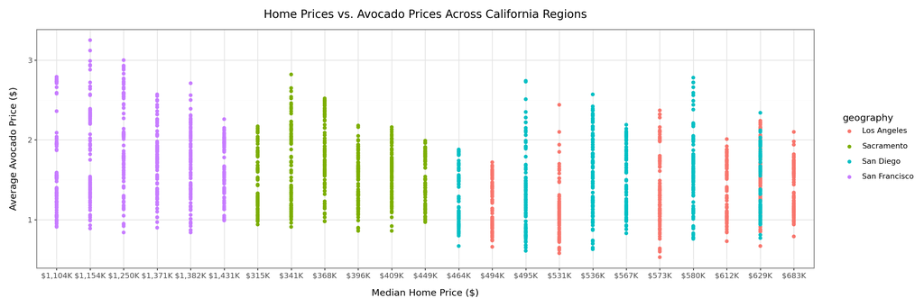

```python
housing_plot = (
    p9.ggplot(avocado_joined, p9.aes(x="median_home_price", y="average_price", color="geography"))
    + p9.geom_point()
    + p9.labs(
        title="Home Prices vs. Avocado Prices Across California Regions",
        x="Median Home Price ($)",
        y="Average Avocado Price ($)"
    )
    + p9.theme_bw()
     + p9.theme(
        figure_size=(15, 5)
    )
)

housing_plot
```

This plot shows that San Francisco with the largest median home prices and the highest average higher avacado prices. Pushing me towards an assumption that when the median home prices are larger the average avocado price will also be larger.